# **Ensemble Techniques Project Solution**

# **PART A**

• DOMAIN: Telecom

• CONTEXT: A telecom company wants to use their historical customer data to predict behaviour to retain customers. You can analyse all relevant customer data and develop focused customer retention programs.

• DATA DESCRIPTION: Each row represents a customer, each column contains customer’s attributes described on the column Metadata. The data set includes information about:

- Customers who left within the last month – the column is called Churn
- Services that each customer has signed up for – phone, multiple lines, internet, online security, online backup, device protection, tech support, and streaming TV and movies
- Customer account information – how long they’ve been a customer, contract, payment method, paperless billing, monthly charges, and total charges
- Demographic info about customers – gender, age range, and if they have partners and dependents

• PROJECT OBJECTIVE: To Build a model that will help to identify the potential customers who have a higher probability to churn. This helps the company to understand the pinpoints and patterns of customer churn and will increase the focus on strategizing customer retention.

## **1. Data Understanding & Exploration**

```python
# Import all the necessary libraries.
import pandas as pd
import numpy as np
import seaborn as sns
import matplotlib.pyplot as plt
%matplotlib inline
from scipy.stats import zscore
```

**A. Read ‘TelcomCustomer-Churn_1.csv’ as a DataFrame and assign it to a variable.**

```python
path = "TelcomCustomer-Churn_1.csv"
df_Churn1 = pd.read_csv(path)
```

```python
df_Churn1.head()
```

|  | customerID | gender | SeniorCitizen | Partner | Dependents | tenure | PhoneService | MultipleLines | InternetService | OnlineSecurity |
| --- | --- | --- | --- | --- | --- | --- | --- | --- | --- | --- |
| 0 | 7590-VHVEG | Female | 0 | Yes | No | 1 | No | No phone service | DSL | No |
| 1 | 5575-GNVDE | Male | 0 | No | No | 34 | Yes | No | DSL | Yes |
| 2 | 3668-QPYBK | Male | 0 | No | No | 2 | Yes | No | DSL | Yes |
| 3 | 7795-CFOCW | Male | 0 | No | No | 45 | No | No phone service | DSL | Yes |
| 4 | 9237-HQITU | Female | 0 | No | No | 2 | Yes | No | Fiber optic | No |

```python
df_Churn1.info()
```

```
<class 'pandas.core.frame.DataFrame'>
RangeIndex: 7043 entries, 0 to 7042
Data columns (total 10 columns):
 #   Column           Non-Null Count  Dtype
---  ------           --------------  -----
 0   customerID       7043 non-null   object
 1   gender           7043 non-null   object
 2   SeniorCitizen    7043 non-null   int64
 3   Partner          7043 non-null   object
 4   Dependents       7043 non-null   object
 5   tenure           7043 non-null   int64
 6   PhoneService     7043 non-null   object
 7   MultipleLines    7043 non-null   object
 8   InternetService  7043 non-null   object
 9   OnlineSecurity   7043 non-null   object
dtypes: int64(2), object(8)
memory usage: 550.4+ KB
```

**Observation:** Churn1 Dataframe has 7043 entries with 10 columns.

**B. Read ‘TelcomCustomer-Churn_2.csv’ as a DataFrame and assign it to a variable.**

```python
path = "TelcomCustomer-Churn_2.csv"
df_Churn2 = pd.read_csv(path)
```

```python
df_Churn2.head()
```

|  | customerID | OnlineBackup | DeviceProtection | TechSupport | StreamingTV | StreamingMovies | Contract | PaperlessBilling | PaymentMethod | MonthlyCharges | TotalCharges | Churn |
| --- | --- | --- | --- | --- | --- | --- | --- | --- | --- | --- | --- | --- |
| 0 | 7590-VHVEG | Yes | No | No | No | No | Month-to-month | Yes | Electronic check | 29.85 | 29.85 | No |
| 1 | 5575-GNVDE | No | Yes | No | No | No | One year | No | Mailed check | 56.95 | 1889.5 | No |
| 2 | 3668-QPYBK | Yes | No | No | No | No | Month-to-month | Yes | Mailed check | 53.85 | 108.15 | Yes |
| 3 | 7795-CFOCW | No | Yes | Yes | No | No | One year | No | Bank transfer (automatic) | 42.30 | 1840.75 | No |
| 4 | 9237-HQITU | No | No | No | No | No | Month-to-month | Yes | Electronic check | 70.70 | 151.65 | Yes |

```python
df_Churn2.info()
```

```
<class 'pandas.core.frame.DataFrame'>
RangeIndex: 7043 entries, 0 to 7042
Data columns (total 12 columns):
 #   Column            Non-Null Count  Dtype
---  ------            --------------  -----
 0   customerID        7043 non-null   object
 1   OnlineBackup      7043 non-null   object
 2   DeviceProtection  7043 non-null   object
 3   TechSupport       7043 non-null   object
 4   StreamingTV       7043 non-null   object
 5   StreamingMovies   7043 non-null   object
 6   Contract          7043 non-null   object
 7   PaperlessBilling  7043 non-null   object
 8   PaymentMethod     7043 non-null   object
 9   MonthlyCharges    7043 non-null   float64
 10  TotalCharges      7043 non-null   object
 11  Churn             7043 non-null   object
dtypes: float64(1), object(11)
memory usage: 660.4+ KB
```

**Observation:** Churn2 Dataframe has 7043 entries with 12 columns. Except customerID column, no other column overlaps between the two dataframes.

**C. Merge both the DataFrames on key ‘customerID’ to form a single DataFrame**

```python
telecom_df = pd.merge(df_Churn1, df_Churn2, on='customerID')

# create a copy to use in Part B
merged_df = telecom_df

telecom_df.head()
```

|  | customerID | gender | SeniorCitizen | Partner | Dependents | tenure | PhoneService | MultipleLines | InternetService | OnlineSecurity | ... | DeviceProtection | TechSupport | StreamingTV | StreamingMovies | Contract | PaperlessBilling | PaymentMethod | MonthlyCharges | TotalCharges | Churn |
| --- | --- | --- | --- | --- | --- | --- | --- | --- | --- | --- | --- | --- | --- | --- | --- | --- | --- | --- | --- | --- | --- |
| 0 | 7590-VHVEG | Female | 0 | Yes | No | 1 | No | No phone service | DSL | No | ... | No | No | No | No | Month-to-month | Yes | Electronic check | 29.85 | 29.85 | No |
| 1 | 5575-GNVDE | Male | 0 | No | No | 34 | Yes | No | DSL | Yes | ... | Yes | No | No | No | One year | No | Mailed check | 56.95 | 1889.5 | No |
| 2 | 3668-QPYBK | Male | 0 | No | No | 2 | Yes | No | DSL | Yes | ... | No | No | No | No | Month-to-month | Yes | Mailed check | 53.85 | 108.15 | Yes |
| 3 | 7795-CFOCW | Male | 0 | No | No | 45 | No | No phone service | DSL | Yes | ... | Yes | Yes | No | No | One year | No | Bank transfer (automatic) | 42.30 | 1840.75 | No |
| 4 | 9237-HQITU | Female | 0 | No | No | 2 | Yes | No | Fiber optic | No | ... | No | No | No | No | Month-to-month | Yes | Electronic check | 70.70 | 151.65 | Yes |

5 rows × 21 columns

**Observations:** The merged dataframe has 7043 entries with 21 columns.

**D. Verify if all the columns are incorporated in the merged DataFrame by using simple comparison Operator in Python.**

```python
if ((set(df_Churn1.columns).issubset(telecom_df.columns)) and ((set(df_Churn2.columns).issubset(telecom_df.columns)))):
   print("All Columns are present")
else:
   print("All Columns are NOT present")
```

```
All Columns are present
```

```python
if ((df_Churn1.shape[0] == telecom_df.shape[0]) and (df_Churn2.shape[0] == telecom_df.shape[0])):
  print("All rows are present")
else:
   print("All rows are NOT present")
```

```
All rows are present
```

```python
#Confirmation:
print("Shape of Dataframe 1       :", df_Churn1.shape)
print("Shape of Dataframe 2       :", df_Churn2.shape)
print("Shape of Merged Dataframe  :", telecom_df.shape)
```

```
Shape of Dataframe 1       : (7043, 10)
Shape of Dataframe 2       : (7043, 12)
Shape of Merged Dataframe  : (7043, 21)
```

**Observation:** From above comparision, it is seen that all the rows and columns of Dataframe 1 and 2 are present in the merged Dataframe.

## **2. Data Cleaning & Analysis**

```python
telecom_df.info()
```

```
<class 'pandas.core.frame.DataFrame'>
Int64Index: 7043 entries, 0 to 7042
Data columns (total 21 columns):
 #   Column            Non-Null Count  Dtype
---  ------            --------------  -----
 0   customerID        7043 non-null   object
 1   gender            7043 non-null   object
 2   SeniorCitizen     7043 non-null   int64
 3   Partner           7043 non-null   object
 4   Dependents        7043 non-null   object
 5   tenure            7043 non-null   int64
 6   PhoneService      7043 non-null   object
 7   MultipleLines     7043 non-null   object
 8   InternetService   7043 non-null   object
 9   OnlineSecurity    7043 non-null   object
 10  OnlineBackup      7043 non-null   object
 11  DeviceProtection  7043 non-null   object
 12  TechSupport       7043 non-null   object
 13  StreamingTV       7043 non-null   object
 14  StreamingMovies   7043 non-null   object
 15  Contract          7043 non-null   object
 16  PaperlessBilling  7043 non-null   object
 17  PaymentMethod     7043 non-null   object
 18  MonthlyCharges    7043 non-null   float64
 19  TotalCharges      7043 non-null   object
 20  Churn             7043 non-null   object
dtypes: float64(1), int64(2), object(18)
memory usage: 1.2+ MB
```

**A. Impute missing/unexpected values in the DataFrame.**

```python
# “TotalCharges” column has the data type “object,” but it should be a numeric column.
# Convert it into a numeric column.
telecom_df['TotalCharges'] = pd.to_numeric(telecom_df['TotalCharges'], errors = 'coerce')
```

```python
#Check unique values of each columns
print("Unique Values of Columns:\n")
for column in set(telecom_df.columns) - {'customerID'}:
    print('{:<20s} \t-  {}'.format(column,telecom_df[column].unique()))
```

```
Unique Values of Columns:

Contract             	-  ['Month-to-month' 'One year' 'Two year']
StreamingTV          	-  ['No' 'Yes' 'No internet service']
gender               	-  ['Female' 'Male']
TechSupport          	-  ['No' 'Yes' 'No internet service']
OnlineSecurity       	-  ['No' 'Yes' 'No internet service']
tenure               	-  [ 1 34  2 45  8 22 10 28 62 13 16 58 49 25 69 52 71 21 12 30 47 72 17 27
  5 46 11 70 63 43 15 60 18 66  9  3 31 50 64 56  7 42 35 48 29 65 38 68
 32 55 37 36 41  6  4 33 67 23 57 61 14 20 53 40 59 24 44 19 54 51 26  0
 39]
TotalCharges         	-  [  29.85 1889.5   108.15 ...  346.45  306.6  6844.5 ]
SeniorCitizen        	-  [0 1]
Partner              	-  ['Yes' 'No']
Dependents           	-  ['No' 'Yes']
Churn                	-  ['No' 'Yes']
PhoneService         	-  ['No' 'Yes']
PaperlessBilling     	-  ['Yes' 'No']
DeviceProtection     	-  ['No' 'Yes' 'No internet service']
PaymentMethod        	-  ['Electronic check' 'Mailed check' 'Bank transfer (automatic)'
 'Credit card (automatic)']
MultipleLines        	-  ['No phone service' 'No' 'Yes']
StreamingMovies      	-  ['No' 'Yes' 'No internet service']
OnlineBackup         	-  ['Yes' 'No' 'No internet service']
MonthlyCharges       	-  [29.85 56.95 53.85 ... 63.1  44.2  78.7 ]
InternetService      	-  ['DSL' 'Fiber optic' 'No']
```

```python
telecom_df.isnull().sum()
```

```
customerID           0
gender               0
SeniorCitizen        0
Partner              0
Dependents           0
tenure               0
PhoneService         0
MultipleLines        0
InternetService      0
OnlineSecurity       0
OnlineBackup         0
DeviceProtection     0
TechSupport          0
StreamingTV          0
StreamingMovies      0
Contract             0
PaperlessBilling     0
PaymentMethod        0
MonthlyCharges       0
TotalCharges        11
Churn                0
dtype: int64
```

```python
#Drop the null values
telecom_df.dropna(inplace=True)
```

```python
# Verify that no NULL values exist
telecom_df.isnull().sum()
```

```
customerID          0
gender              0
SeniorCitizen       0
Partner             0
Dependents          0
tenure              0
PhoneService        0
MultipleLines       0
InternetService     0
OnlineSecurity      0
OnlineBackup        0
DeviceProtection    0
TechSupport         0
StreamingTV         0
StreamingMovies     0
Contract            0
PaperlessBilling    0
PaymentMethod       0
MonthlyCharges      0
TotalCharges        0
Churn               0
dtype: int64
```

```python
# Remove (automatic) from payment method values for easy data handling
telecom_df['PaymentMethod']=telecom_df['PaymentMethod'].str.replace('(automatic)', '', regex = False)
```

**B. Make sure all the variables with continuous values are of ‘Float’ type.**

```python
telecom_df.describe().T
```

|  | count | mean | std | min | 25% | 50% | 75% | max |
| --- | --- | --- | --- | --- | --- | --- | --- | --- |
| SeniorCitizen | 7032.0 | 0.162400 | 0.368844 | 0.00 | 0.0000 | 0.000 | 0.0000 | 1.00 |
| tenure | 7032.0 | 32.421786 | 24.545260 | 1.00 | 9.0000 | 29.000 | 55.0000 | 72.00 |
| MonthlyCharges | 7032.0 | 64.798208 | 30.085974 | 18.25 | 35.5875 | 70.350 | 89.8625 | 118.75 |
| TotalCharges | 7032.0 | 2283.300441 | 2266.771362 | 18.80 | 401.4500 | 1397.475 | 3794.7375 | 8684.80 |

```python
# Numerical columns of Interest: tenure, monthly charges, total charges --> Covert this to Float skipping the ones which are already float
telecom_df['tenure']         = telecom_df['tenure'].astype('float')
telecom_df['TotalCharges']   = telecom_df['TotalCharges'].astype('float')
```

```python
telecom_df.info()
```

```
<class 'pandas.core.frame.DataFrame'>
Int64Index: 7032 entries, 0 to 7042
Data columns (total 21 columns):
 #   Column            Non-Null Count  Dtype
---  ------            --------------  -----
 0   customerID        7032 non-null   object
 1   gender            7032 non-null   object
 2   SeniorCitizen     7032 non-null   int64
 3   Partner           7032 non-null   object
 4   Dependents        7032 non-null   object
 5   tenure            7032 non-null   float64
 6   PhoneService      7032 non-null   object
 7   MultipleLines     7032 non-null   object
 8   InternetService   7032 non-null   object
 9   OnlineSecurity    7032 non-null   object
 10  OnlineBackup      7032 non-null   object
 11  DeviceProtection  7032 non-null   object
 12  TechSupport       7032 non-null   object
 13  StreamingTV       7032 non-null   object
 14  StreamingMovies   7032 non-null   object
 15  Contract          7032 non-null   object
 16  PaperlessBilling  7032 non-null   object
 17  PaymentMethod     7032 non-null   object
 18  MonthlyCharges    7032 non-null   float64
 19  TotalCharges      7032 non-null   float64
 20  Churn             7032 non-null   object
dtypes: float64(3), int64(1), object(17)
memory usage: 1.2+ MB
```

**C. Create a function that will accept a DataFrame as input and return pie-charts for all the appropriate Categorical features. Clearly show percentage distribution in the pie-chart.**

```python
import math
from matplotlib.gridspec import GridSpec
# The function returns pie-charts for all the appropriate Categorical features of a data frame.
# Input : Dataframe(df)
# Output: Plots pie charts for all categorical features.

def display_pie_charts_for_Cat_features(df):
    # List all the categorical column names in variable 'categorical_features'
    categorical_features = df.select_dtypes(['object','category']).columns.to_list()

    # Skip Customer ID column as it is not needed
    categorical_features.remove('customerID')

    # Derive the num of rows required for subplot display. Assume num of col in grid is 3.
    ncol = len(categorical_features)
    nrow = math.ceil(ncol/3)

    # Set the Color Map for Pie Chart
    cmap = plt.cm.prism
    cmap = plt.get_cmap('Accent')
    my_colors = [cmap(i) for i in np.linspace(0, 1, 8)]
    fig, ax = plt.subplots(figsize=(15, 30))

    # Counter to point at the location in grid
    count = 1

    for i in categorical_features:
      plt.subplot(nrow, 3, count)
      axes = df[i].value_counts().plot(kind ='pie', autopct='%1.1f%%',fontsize=12, colors = my_colors, wedgeprops = { 'linewidth' : 3, 'edgecolor' : 'white' })
      axes.set_ylabel('')
      axes.set_title(i.upper(),fontsize=20)
      count += 1

    fig.tight_layout(pad=5.0)
    plt.show();
```

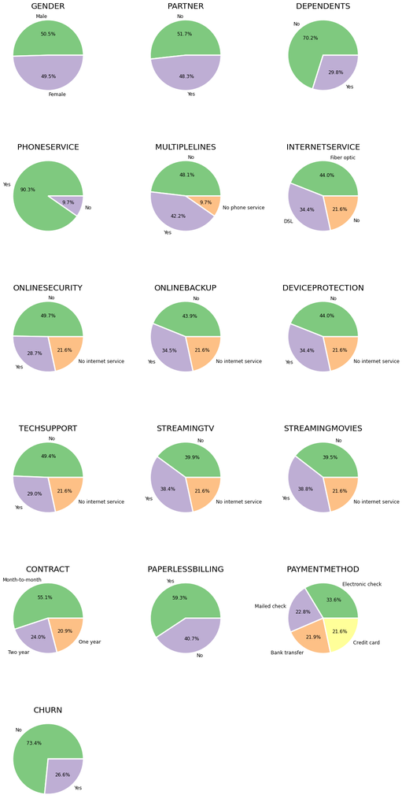

```python
display_pie_charts_for_Cat_features(telecom_df)
```

**E. Encode all the appropriate Categorical features with the best suitable approach.**

```python
telecom_df.head(8)
```

|  | customerID | gender | SeniorCitizen | Partner | Dependents | tenure | PhoneService | MultipleLines | InternetService | OnlineSecurity | ... | DeviceProtection | TechSupport | StreamingTV | StreamingMovies | Contract | PaperlessBilling | PaymentMethod | MonthlyCharges | TotalCharges | Churn |
| --- | --- | --- | --- | --- | --- | --- | --- | --- | --- | --- | --- | --- | --- | --- | --- | --- | --- | --- | --- | --- | --- |
| 0 | 7590-VHVEG | Female | 0 | Yes | No | 1.0 | No | No phone service | DSL | No | ... | No | No | No | No | Month-to-month | Yes | Electronic check | 29.85 | 29.85 | No |
| 1 | 5575-GNVDE | Male | 0 | No | No | 34.0 | Yes | No | DSL | Yes | ... | Yes | No | No | No | One year | No | Mailed check | 56.95 | 1889.50 | No |
| 2 | 3668-QPYBK | Male | 0 | No | No | 2.0 | Yes | No | DSL | Yes | ... | No | No | No | No | Month-to-month | Yes | Mailed check | 53.85 | 108.15 | Yes |
| 3 | 7795-CFOCW | Male | 0 | No | No | 45.0 | No | No phone service | DSL | Yes | ... | Yes | Yes | No | No | One year | No | Bank transfer | 42.30 | 1840.75 | No |
| 4 | 9237-HQITU | Female | 0 | No | No | 2.0 | Yes | No | Fiber optic | No | ... | No | No | No | No | Month-to-month | Yes | Electronic check | 70.70 | 151.65 | Yes |
| 5 | 9305-CDSKC | Female | 0 | No | No | 8.0 | Yes | Yes | Fiber optic | No | ... | Yes | No | Yes | Yes | Month-to-month | Yes | Electronic check | 99.65 | 820.50 | Yes |
| 6 | 1452-KIOVK | Male | 0 | No | Yes | 22.0 | Yes | Yes | Fiber optic | No | ... | No | No | Yes | No | Month-to-month | Yes | Credit card | 89.10 | 1949.40 | No |
| 7 | 6713-OKOMC | Female | 0 | No | No | 10.0 | No | No phone service | DSL | Yes | ... | No | No | No | No | Month-to-month | No | Mailed check | 29.75 | 301.90 | No |

8 rows × 21 columns

**Observation:**

The above data can be categorized as follows:

1. Categorical features: gender, streaming tv, payment method &, etc.
2. Numerical features: tenure, monthly charges, total charges

For categorical features:

- Apply Label Encoder to categorical features which are binary
- Apply get_dummies() to categorical features which have multiple values

```python
telecom_df.dtypes
```

```
customerID           object
gender               object
SeniorCitizen         int64
Partner              object
Dependents           object
tenure              float64
PhoneService         object
MultipleLines        object
InternetService      object
OnlineSecurity       object
OnlineBackup         object
DeviceProtection     object
TechSupport          object
StreamingTV          object
StreamingMovies      object
Contract             object
PaperlessBilling     object
PaymentMethod        object
MonthlyCharges      float64
TotalCharges        float64
Churn                object
dtype: object
```

SeniorCitizen is already having Values as 0 or 1. This can be skipped.

```python
# Target Variable 'Churn' is of object dtype. Convert it into Binary values (use Yes=1, No=0)
telecom_df.loc[telecom_df.Churn == 'No','Churn'] = 0
telecom_df.loc[telecom_df.Churn == 'Yes','Churn'] = 1
telecom_df["Churn"].value_counts()
```

```
0    5163
1    1869
Name: Churn, dtype: int64
```

```python
#import Label Encoder
from sklearn.preprocessing import LabelEncoder
le = LabelEncoder()

# Define an array to store non-binary columns
nonBinaryCol = []

for col in telecom_df.columns:
    if (telecom_df[col].dtype == object):
        if (telecom_df[col].nunique() == 2):
            # Apply Label Encoder
            telecom_df[col] = le.fit_transform(telecom_df[col])
        else:
            nonBinaryCol.append(col)

# Skip CustomerID column for encoding
nonBinaryCol.remove('customerID')

# Now apply # One Hot Encoding for columns that are not binary.
telecom_df = pd.get_dummies(data = telecom_df, columns = nonBinaryCol)
```

```python
telecom_df.dtypes
```

```
customerID                               object
gender                                    int64
SeniorCitizen                             int64
Partner                                   int64
Dependents                                int64
tenure                                  float64
PhoneService                              int64
PaperlessBilling                          int64
MonthlyCharges                          float64
TotalCharges                            float64
Churn                                     int64
MultipleLines_No                          uint8
MultipleLines_No phone service            uint8
MultipleLines_Yes                         uint8
InternetService_DSL                       uint8
InternetService_Fiber optic               uint8
InternetService_No                        uint8
OnlineSecurity_No                         uint8
OnlineSecurity_No internet service        uint8
OnlineSecurity_Yes                        uint8
OnlineBackup_No                           uint8
OnlineBackup_No internet service          uint8
OnlineBackup_Yes                          uint8
DeviceProtection_No                       uint8
DeviceProtection_No internet service      uint8
DeviceProtection_Yes                      uint8
TechSupport_No                            uint8
TechSupport_No internet service           uint8
TechSupport_Yes                           uint8
StreamingTV_No                            uint8
StreamingTV_No internet service           uint8
StreamingTV_Yes                           uint8
StreamingMovies_No                        uint8
StreamingMovies_No internet service       uint8
StreamingMovies_Yes                       uint8
Contract_Month-to-month                   uint8
Contract_One year                         uint8
Contract_Two year                         uint8
PaymentMethod_Bank transfer               uint8
PaymentMethod_Credit card                 uint8
PaymentMethod_Electronic check            uint8
PaymentMethod_Mailed check                uint8
dtype: object
```

```python
telecom_df.head(8)
```

|  | customerID | gender | SeniorCitizen | Partner | Dependents | tenure | PhoneService | PaperlessBilling | MonthlyCharges | TotalCharges | ... | StreamingMovies_No | StreamingMovies_No internet service | StreamingMovies_Yes | Contract_Month-to-month | Contract_One year | Contract_Two year | PaymentMethod_Bank transfer | PaymentMethod_Credit card | PaymentMethod_Electronic check | PaymentMethod_Mailed check |
| --- | --- | --- | --- | --- | --- | --- | --- | --- | --- | --- | --- | --- | --- | --- | --- | --- | --- | --- | --- | --- | --- |
| 0 | 7590-VHVEG | 0 | 0 | 1 | 0 | 1.0 | 0 | 1 | 29.85 | 29.85 | ... | 1 | 0 | 0 | 1 | 0 | 0 | 0 | 0 | 1 | 0 |
| 1 | 5575-GNVDE | 1 | 0 | 0 | 0 | 34.0 | 1 | 0 | 56.95 | 1889.50 | ... | 1 | 0 | 0 | 0 | 1 | 0 | 0 | 0 | 0 | 1 |
| 2 | 3668-QPYBK | 1 | 0 | 0 | 0 | 2.0 | 1 | 1 | 53.85 | 108.15 | ... | 1 | 0 | 0 | 1 | 0 | 0 | 0 | 0 | 0 | 1 |
| 3 | 7795-CFOCW | 1 | 0 | 0 | 0 | 45.0 | 0 | 0 | 42.30 | 1840.75 | ... | 1 | 0 | 0 | 0 | 1 | 0 | 1 | 0 | 0 | 0 |
| 4 | 9237-HQITU | 0 | 0 | 0 | 0 | 2.0 | 1 | 1 | 70.70 | 151.65 | ... | 1 | 0 | 0 | 1 | 0 | 0 | 0 | 0 | 1 | 0 |
| 5 | 9305-CDSKC | 0 | 0 | 0 | 0 | 8.0 | 1 | 1 | 99.65 | 820.50 | ... | 0 | 0 | 1 | 1 | 0 | 0 | 0 | 0 | 1 | 0 |
| 6 | 1452-KIOVK | 1 | 0 | 0 | 1 | 22.0 | 1 | 1 | 89.10 | 1949.40 | ... | 1 | 0 | 0 | 1 | 0 | 0 | 0 | 1 | 0 | 0 |
| 7 | 6713-OKOMC | 0 | 0 | 0 | 0 | 10.0 | 0 | 0 | 29.75 | 301.90 | ... | 1 | 0 | 0 | 1 | 0 | 0 | 0 | 0 | 0 | 1 |

8 rows × 42 columns

**F. Split the data into 80% train and 20% test.**

```python
from sklearn.model_selection import train_test_split
X = telecom_df.drop(['Churn','customerID'],axis=1)
y = telecom_df['Churn']

X_train, X_test, y_train, y_test = train_test_split(X, y, test_size=0.2, random_state=0, stratify = y)
```

```python
print(X_train.shape)
print(X_test.shape)
print(y_train.shape)
print(y_test.shape)
```

```
(5625, 40)
(1407, 40)
(5625,)
(1407,)
```

**G. Normalize/Standardize the data with the best suitable approach.**

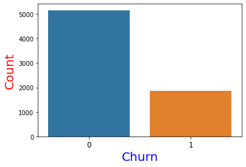

```
Value Count of Churn Variables:
0    5163
1    1869
Name: Churn, dtype: int64
```

```python
# Plot the distribution of Target variable
sns.countplot(x = "Churn", data = telecom_df)
plt.xticks(fontsize = 12)
plt.xlabel("Churn", fontsize = 20, c= "b")
plt.ylabel("Count", fontsize = 20, c= "r")
plt.show()

print("\nValue Count of Churn Variables:")
print(telecom_df["Churn"].value_counts())
```

**Observation:** As seen in the graph above, the dataset is imbalanced which means that a majority of values in the target variable belong to a single class. Most customers in the dataset did not churn - only 27% of them did.

To overcome class imbalance problem, we will use oversampling.

```python
# We should oversample solely on the training dataset, as the test dataset must be representative of the true population.
from imblearn.over_sampling import SMOTE

oversample = SMOTE(k_neighbors=5)
X_smote, y_smote = oversample.fit_resample(X_train, y_train)
X_train, y_train = X_smote, y_smote
```

```python
y_train.value_counts()
```

```
0    4130
1    4130
Name: Churn, dtype: int64
```

**Observation:** Now the training dataset is balanced.

```python
# Now lets look at Standardization/Scaling for numerical features
from sklearn.preprocessing import StandardScaler
num_cols = ["MonthlyCharges", "TotalCharges", "tenure"]
scaler = StandardScaler()
telecom_df[num_cols] = scaler.fit_transform(telecom_df[num_cols])
telecom_df.sample(5)
```

|  | customerID | gender | SeniorCitizen | Partner | Dependents | tenure | PhoneService | PaperlessBilling | MonthlyCharges | TotalCharges | ... | StreamingMovies_No | StreamingMovies_No internet service | StreamingMovies_Yes | Contract_Month-to-month | Contract_One year | Contract_Two year | PaymentMethod_Bank transfer | PaymentMethod_Credit card | PaymentMethod_Electronic check | PaymentMethod_Mailed check |
| --- | --- | --- | --- | --- | --- | --- | --- | --- | --- | --- | --- | --- | --- | --- | --- | --- | --- | --- | --- | --- | --- |
| 3547 | 1568-BEKZM | 1 | 1 | 1 | 0 | 1.531085 | 1 | 0 | 0.839381 | 1.786853 | ... | 0 | 0 | 1 | 0 | 0 | 1 | 0 | 1 | 0 | 0 |
| 1628 | 6267-DCFFZ | 0 | 1 | 1 | 0 | -0.098673 | 1 | 1 | 0.839381 | 0.151724 | ... | 1 | 0 | 0 | 1 | 0 | 0 | 0 | 0 | 1 | 0 |
| 5411 | 7932-WPTDS | 0 | 1 | 1 | 0 | -1.280248 | 0 | 1 | -1.329558 | -0.996422 | ... | 1 | 0 | 0 | 1 | 0 | 0 | 0 | 0 | 1 | 0 |
| 6161 | 4343-EJVQB | 1 | 0 | 0 | 0 | -1.035784 | 1 | 0 | 0.317506 | -0.771946 | ... | 1 | 0 | 0 | 1 | 0 | 0 | 0 | 0 | 0 | 1 |
| 4186 | 7572-KPVKK | 1 | 0 | 0 | 1 | 1.205134 | 1 | 1 | 1.304747 | 1.900282 | ... | 0 | 0 | 1 | 0 | 0 | 1 | 0 | 0 | 1 | 0 |

5 rows × 42 columns

## **3. Model building and Improvement**

**A. Train a model using XGBoost. Also print best performing parameters along with train and test performance.**

```python
import xgboost as xgb  #import xgbost model
from sklearn.metrics import accuracy_score,confusion_matrix,roc_auc_score,ConfusionMatrixDisplay,precision_score,recall_score,f1_score,classification_report,roc_curve,plot_roc_curve,auc,precision_recall_curve,plot_precision_recall_curve,average_precision_score
from sklearn.model_selection import GridSearchCV, cross_val_score

# Instantiating the basic model
xgb_model_basic = xgb.XGBClassifier(random_state=0)
xgb_model_basic.fit(X_train, y_train)
y_pred_basic = xgb_model_basic.predict(X_test)
y_train_pred_basic = xgb_model_basic.predict(X_train)

print('-'*40)
print("Confusion Matrix:")
print(confusion_matrix(y_test,y_pred_basic))
print('-'*40)
print("Classification report:")
print(classification_report(y_test, y_pred_basic))
print('-'*40)
print('Train Accuracy Score:\t{:.2f}'.format(accuracy_score(y_train, y_train_pred_basic)))
print('\nTest Accuracy Score:\t{:.2f} '.format(accuracy_score(y_test,y_pred_basic)))
print('\nROC AUC Score:\t\t{:.2f} '.format(roc_auc_score(y_test,y_pred_basic)))
print('\nPrecision:\t\t{:.2f} '.format(precision_score(y_test,y_pred_basic)))
print('\nRecall:\t\t\t{:.2f} '.format(recall_score(y_test,y_pred_basic)))
print('\nF1 Score:\t\t{:.2f} '.format(f1_score(y_test,y_pred_basic)))
print('-'*40)
```

```
----------------------------------------
Confusion Matrix:
[[865 168]
 [137 237]]
----------------------------------------
Classification report:
              precision    recall  f1-score   support

           0       0.86      0.84      0.85      1033
           1       0.59      0.63      0.61       374

    accuracy                           0.78      1407
   macro avg       0.72      0.74      0.73      1407
weighted avg       0.79      0.78      0.79      1407

----------------------------------------
Train Accuracy Score:	0.86

Test Accuracy Score:	0.78

ROC AUC Score:		0.74

Precision:		0.59

Recall:			0.63

F1 Score:		0.61
----------------------------------------
```

**Observation:**

From Basic XGBoost model, we get

Train Accuracy - 86%

Test Accuracy - 78%

Variance is 8%

Recall which tells how many customer churn are predicted correctly with our model.So prediction of customer churn (Recall) is most important parameter to decide the best model for this problem.

```python
# Hyperparameter optimization using RandomizedSearchCV
from sklearn.model_selection import RandomizedSearchCV,StratifiedKFold
import xgboost

classifier = xgboost.XGBClassifier(random_state=0)
skfold = StratifiedKFold(n_splits=5)
params = {
  'n_estimators' : [25, 50 ,75, 100, 200],
  'learning_rate': [0.005 ,0.05, 0.5, 1.5],
  'min_child_weight'  : [ 1, 3, 5, 7 ],
  'max_depth': [2, 4, 6, 8],
  'max_features': [10, 12, 17]
}

xgb_rs_model=RandomizedSearchCV(classifier, param_distributions = params, n_iter=5, scoring='recall', n_jobs=-1, cv=skfold, verbose=3)

# Model fitting
xgb_rs_model.fit(X_train, y_train)
```

```
Fitting 5 folds for each of 5 candidates, totalling 25 fits
```

```
RandomizedSearchCV(cv=StratifiedKFold(n_splits=5, random_state=None, shuffle=False),
                   estimator=XGBClassifier(), n_iter=5, n_jobs=-1,
                   param_distributions={'learning_rate': [0.005, 0.05, 0.5,
                                                          1.5],
                                        'max_depth': [2, 4, 6, 8],
                                        'max_features': [10, 12, 17],
                                        'min_child_weight': [1, 3, 5, 7],
                                        'n_estimators': [25, 50, 75, 100, 200]},
                   scoring='recall', verbose=3)
```

```python
# parameters selected
xgb_rs_model.best_estimator_
```

```
XGBClassifier(learning_rate=0.005, max_depth=6, max_features=17,
              min_child_weight=3, n_estimators=200)
```

```python
# Use the above best parameters and build the model again.
xgb_model_random_best = xgb.XGBClassifier(random_state=0, learning_rate=0.005, max_depth=6, max_features=17,min_child_weight=3, n_estimators=200)
xgb_model_random_best.fit(X_train, y_train)
y_pred_random_best = xgb_model_random_best.predict(X_test)
y_train_pred_random_best = xgb_model_random_best.predict(X_train)

print('-'*40)
print("Confusion Matrix:")
print(confusion_matrix(y_test,y_pred_random_best))
print('-'*40)
print("Classification report:")
print(classification_report(y_test, y_pred_random_best))
print('-'*40)
print('Train Accuracy Score:\t{:.2f}'.format(accuracy_score(y_train, y_train_pred_random_best)))
print('\nTest Accuracy Score:\t{:.2f} '.format(accuracy_score(y_test,y_pred_random_best)))
print('\nROC AUC Score:\t\t{:.2f} '.format(roc_auc_score(y_test,y_pred_random_best)))
print('\nPrecision:\t\t{:.2f} '.format(precision_score(y_test,y_pred_random_best)))
print('\nRecall:\t\t\t{:.2f} '.format(recall_score(y_test,y_pred_random_best)))
print('\nF1 Score:\t\t{:.2f} '.format(f1_score(y_test,y_pred_random_best)))
print('-'*40)
```

```
----------------------------------------
Confusion Matrix:
[[829 204]
 [120 254]]
----------------------------------------
Classification report:
              precision    recall  f1-score   support

           0       0.87      0.80      0.84      1033
           1       0.55      0.68      0.61       374

    accuracy                           0.77      1407
   macro avg       0.71      0.74      0.72      1407
weighted avg       0.79      0.77      0.78      1407

----------------------------------------
Train Accuracy Score:	0.86

Test Accuracy Score:	0.77

ROC AUC Score:		0.74

Precision:		0.55

Recall:			0.68

F1 Score:		0.61
----------------------------------------
```

**Observation:**

Randomised Search with XGboost gives:

Train Accuracy - 86%

Test Accuracy - 77%

Variance = 9%

Recall - 68%

This is clearly better than Base model with higher Recall.

**B. Improve performance of the XGBoost as much as possible. Also print best performing parameters along with train and test performance.**

```python
from sklearn.model_selection import GridSearchCV

xgb_classifier = xgb.XGBClassifier(random_state=0)
params = {
  'n_estimators' : [25, 50 , 75],
  'learning_rate': [0.005 ,0.05, 0.5],
  'max_depth': [2, 4, 6],
  'max_features': [10, 12, 17],
  'min_child_weight' : [ 1, 3, 5 ],
  'gamma' : [ 0.0, 0.1]
}

xgb_gs_model = GridSearchCV(xgb_classifier, params, n_jobs=3, cv=4, scoring = 'recall')
xgb_gs_model.fit(X_train, y_train)

print(xgb_gs_model.best_estimator_)
print('\n')
print(xgb_gs_model.get_params)
print('\n')
print(xgb_gs_model.best_score_)
```

```
XGBClassifier(gamma=0.0, learning_rate=0.05, max_depth=4, max_features=10,
              min_child_weight=3, n_estimators=25)


<bound method BaseEstimator.get_params of GridSearchCV(cv=4, estimator=XGBClassifier(), n_jobs=3,
             param_grid={'gamma': [0.0, 0.1],
                         'learning_rate': [0.005, 0.05, 0.5],
                         'max_depth': [2, 4, 6], 'max_features': [10, 12, 17],
                         'min_child_weight': [1, 3, 5],
                         'n_estimators': [25, 50, 75]},
             scoring='recall')>


0.8808280240437651
```

```python
# Use the above best parameters and build the model again.
xgb_model_grid_best = xgb.XGBClassifier(random_state=0, gamma=0.0, learning_rate=0.05, max_depth=4, max_features=10, min_child_weight=3, n_estimators=25)
xgb_model_grid_best.fit(X_train, y_train)
y_pred_grid_best = xgb_model_grid_best.predict(X_test)
y_train_pred_grid_best = xgb_model_grid_best.predict(X_train)

print("\nConfusion Matrix:")
print(confusion_matrix(y_test,y_pred_grid_best))
print("\nClassification report:")
print(classification_report(y_test, y_pred_grid_best))
print('\nTrain Accuracy Score: ',accuracy_score(y_train, y_train_pred_grid_best))
print('\nTest Accuracy Score: ',accuracy_score(y_test,y_pred_grid_best))
print('\nROC AUC Score: ', roc_auc_score(y_test,y_pred_grid_best))
print('\nPrecision: ', precision_score(y_test,y_pred_grid_best))
print('\nRecall: ', recall_score(y_test,y_pred_grid_best))
print('\nF1 Score: ',  f1_score(y_test,y_pred_grid_best))
print('-'*40)
```

```
Confusion Matrix:
[[792 241]
 [ 96 278]]

Classification report:
              precision    recall  f1-score   support

           0       0.89      0.77      0.82      1033
           1       0.54      0.74      0.62       374

    accuracy                           0.76      1407
   macro avg       0.71      0.76      0.72      1407
weighted avg       0.80      0.76      0.77      1407


Train Accuracy Score:  0.8357142857142857

Test Accuracy Score:  0.7604832977967306

ROC AUC Score:  0.7550072215808791

Precision:  0.535645472061657

Recall:  0.7433155080213903

F1 Score:  0.6226203807390818
----------------------------------------
```

**Observation:**

With Grid Search XGBoost Model:

Train Accuracy - 83%

Test Accuracy - 76%

Variance - 7%

Also, Recall is 74% which is higher compared to base and random search method.

For our final model, we will go with Grid Search with best params suggested. We can fine tune the grid search to increase precision a bit.

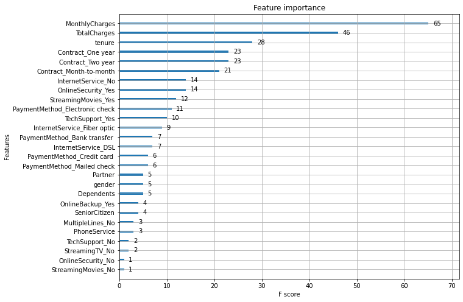

```python
from xgboost import plot_importance

fig, ax = plt.subplots(figsize=(10,8))
plot_importance(xgb_model_grid_best, ax=ax);
```

```python
telecom_df['proba'] = xgb_model_grid_best.predict_proba(telecom_df[X_train.columns])[:,1]

telecom_df[['customerID', 'proba']].head()
```

|  | customerID | proba |
| --- | --- | --- |
| 0 | 7590-VHVEG | 0.666462 |
| 1 | 5575-GNVDE | 0.198188 |
| 2 | 3668-QPYBK | 0.566746 |
| 3 | 7795-CFOCW | 0.198188 |
| 4 | 9237-HQITU | 0.745918 |

**Observation**

From above, we can know customers who are likely to churn and take necessary actions based on it.

# **PART B**

• DOMAIN: IT

• CONTEXT: The purpose is to build a machine learning workflow that will work autonomously irrespective of Data and users can save efforts involved in building workflows for each dataset.

• PROJECT OBJECTIVE: Build a machine learning workflow that will run autonomously with the csv file and return best performing model.

1. Build a simple ML workflow which will accept a single ‘.csv’ file as input and return a trained base model that can be used for predictions. You can use 1 Dataset from Part 1 (single/merged).
2. Create separate functions for various purposes.
3. Various base models should be trained to select the best performing model.
4. Pickle file should be saved for the best performing model.

   Include best coding practices in the code:
- Modularization
- Maintainability
- Well commented code etc

```python
def copy_dataframe(dataframe):
  return dataframe.copy()
```

```python
########################################## DATA PREPROCESSING ###############################
# for data manipulation
import numpy as np
import pandas as pd

# for data splitting, transforming and model training
from sklearn.metrics import accuracy_score, precision_score, recall_score, f1_score,roc_auc_score
from sklearn.model_selection import train_test_split
from sklearn.model_selection import GridSearchCV, cross_validate
from sklearn.preprocessing import LabelEncoder
from sklearn.preprocessing import StandardScaler

# Import Warnings
import warnings
warnings.simplefilter(action="ignore")

# Data reading
def read_data(df):
  print(20*"-" + "Information".center(20) + 20*"-")
  print(df.info())
  print(20*"-" + "Data Shape".center(20) + 20*"-")
  print(df.shape)
  print("\n" + 20*"-" + "Sample Data".center(20) + 20*"-")
  print(df.head())
  print("\n" + 40 * "-" + "Describe the Data".center(40) + 40 * "-")
  print(df.describe([0.01, 0.05, 0.10, 0.50, 0.75, 0.90, 0.95, 0.99]).T)

def handle_missing_val(df_copy):
  # “TotalCharges” column has the data type “object,” but it should be a numeric column. Convert
  df_copy['TotalCharges'] = pd.to_numeric(df_copy['TotalCharges'], errors = 'coerce')

  # Check Missing Values
  df_copy.isnull().sum()

  # Drop the null values
  df_copy.dropna(inplace=True)

  # Verify that no NULL values exist
  df_copy.isnull().sum()

# Dropping ALL duplicate values
def handle_dup_val(df_copy):
  df_copy.drop_duplicates(subset="customerID", keep=False, inplace=True)

# Data cleaning
def clean_data(df_copy):

  # Remove (automatic) from payment method values for easy data handling
  df_copy['PaymentMethod'] = df_copy['PaymentMethod'].str.replace('(automatic)', '', regex = False)

  # Divide customers into bins based on tenure. Get the max tenure
  print(df_copy['tenure'].max())

  # Here we will try to group the tenures
  labels = ["{0} - {1}".format(i, i + 11) for i in range(1, 72, 12)]
  df_copy['tenure_group'] = pd.cut(df_copy.tenure, range(1, 80, 12), right=False, labels=labels)

  print(df_copy['tenure_group'].value_counts())

  # Data Type conversion where needed
  print(df_copy.describe().T)

  # Numerical columns of Interest: monthly charges, total charges
  df_copy['TotalCharges'] = df_copy['TotalCharges'].astype('float')
  df_copy['TotalCharges'] = df_copy['MonthlyCharges'].astype('float')

# Drop Unwanted features
def drop_unwanted_feat(df_copy):
  # Drop column tenure.
  # CustomerID is needed to make Prabability analysis later
  df_copy.drop(columns = ['tenure'], axis=1, inplace=True)

  print("\n\n" + 20*"-" + "Information".center(20) + 20*"-")
  print(df_copy.info())
  print('-'*80)

# Function to preprocess the data
def preprocess_data(dataframe):

  # Data Reading
  read_data(dataframe)

  # Make a copy of the data to preprocess it further.
  df_copy = copy_dataframe(dataframe)

  # Impute missing values
  handle_missing_val(df_copy)

  # Impute duplicate values
  handle_dup_val(df_copy)

  # Data cleaning
  clean_data(df_copy)

  # Dropping unnecessary features
  drop_unwanted_feat(df_copy)

  return df_copy
```

```python
########################################## DATA VISUALIZATION #################################
import matplotlib.pyplot as plt
import seaborn as sns

import math
from matplotlib.gridspec import GridSpec
# The function returns pie-charts for all the appropriate Categorical features of a data frame.
# Input : Dataframe(df)
# Output: Plots pie charts for all categorical features.

def display_pie_charts_for_Cat_features(df):
    # List all the categorical column names in variable 'categorical_features'
    categorical_features = df.select_dtypes(['object','category']).columns.to_list()

    # Skip Customer ID column as it is not needed
    categorical_features.remove('customerID')

    # Derive the num of rows required for subplot display. Assume num of col in grid is 3.
    ncol = len(categorical_features)
    nrow = math.ceil(ncol/3)

    # Set the Color Map for Pie Chart
    cmap = plt.cm.prism
    cmap = plt.get_cmap('Accent')
    my_colors = [cmap(i) for i in np.linspace(0, 1, 8)]
    fig, ax = plt.subplots(figsize=(15, 30))

    # Counter to point at the location in grid
    count = 1

    for i in categorical_features:
      plt.subplot(nrow, 3, count)
      axes = df[i].value_counts().plot(kind ='pie', autopct='%1.1f%%',fontsize=12, colors = my_colors, wedgeprops = { 'linewidth' : 3, 'edgecolor' : 'white' })
      axes.set_ylabel('')
      axes.set_title(i.upper(),fontsize=20)
      count += 1

    fig.tight_layout(pad=5.0)
    plt.show();

def explore_data(df):

  # Get the names of categorical, numerical and categorical but cardinal variables
  cat_cols, num_cols, cat_but_car = grab_col_names(df)

  # Univariate Analysis
  # Plot distibution of individual predictors by churn
  for i, predictor in enumerate(df.drop(columns=['customerID', 'Churn', 'TotalCharges', 'MonthlyCharges'])):
    plt.figure(i)
    sns.countplot(data = df, x=predictor, hue='Churn')

  # Perform target variable analysis
  print("\n----------- Target Variable Analysis ----------------- \n ")
  for col in num_cols:
    print(df.groupby('Churn').agg({col: "mean"}), end="\n\n")

  # Perform outlier observation analysis
  print("\n------------ Outlier Analysis ------------------------ \n")
  for col in num_cols:
    print("Feature : {}, Outlier Impact: {}".format(col, check_outlier(df, col)))

  print('-'*40)
  print("\n\n")

  display_pie_charts_for_Cat_features(df)
```

```python
################################################# DATA ENCODING #########################################
from sklearn.preprocessing import LabelEncoder

def grab_col_names(df, cat_th=10, car_th=20):

  """
  It gives the names of categorical, numerical and categorical but cardinal variables in the data set.
  Note: Categorical variables with numerical appearance are also included in categorical variables.

  Parameters:
  -----------
  df    : Dataframe      (The dataframe from which variable names are to be retrieved)
  cat_th: int, optional  (threshold value for numeric but categorical variables)
  car_th: int, optinal   (threshold value for categorical but cardinal variables)

  Returns:
  --------
  cat_cols: list         (Categorical variable list)
  num_cols: list         (Numeric variable list)
  cat_but_car: list      (Categorical but cardinal variable list)

  Notes:
  ------
  cat_cols + num_cols + cat_but_car = total number of variables
  num_but_cat is inside cat_cols.
  The sum of the 3 returned lists equals the total number of variables:
  cat_cols + num_cols + cat_but_car = number of variables
  """
  # cat_cols, cat_but_car
  cat_cols    = [col for col in df.columns if df[col].dtypes == "O"]
  num_but_cat = [col for col in df.columns if df[col].nunique() < cat_th and df[col].dtypes != "O"]
  cat_but_car = [col for col in df.columns if df[col].nunique() > car_th and df[col].dtypes == "O"]
  cat_cols    = cat_cols + num_but_cat
  cat_cols    = [col for col in cat_cols if col not in cat_but_car]

  # num_cols
  num_cols    = [col for col in df.columns if df[col].dtypes != "O"]
  num_cols    = [col for col in num_cols if col not in num_but_cat]

  return cat_cols, num_cols, cat_but_car

def outlier_thresholds(df, col_name, q1=0.05, q3=0.95):
    quartile1 = df[col_name].quantile(q1)
    quartile3 = df[col_name].quantile(q3)
    interquantile_range = quartile3 - quartile1
    up_limit = quartile3 + 1.5 * interquantile_range
    low_limit = quartile1 - 1.5 * interquantile_range
    return low_limit, up_limit

def check_outlier(df, col_name):
    low_limit, up_limit = outlier_thresholds(df, col_name)
    if (df[(df[col_name] > up_limit) | (df[col_name] < low_limit)].any(axis=None)):
        return True
    else:
        return False

def grab_outliers(df, col_name, index=False):
    low, up = outlier_thresholds(df, col_name)

    if (df[((df[col_name] < low) | (df[col_name] > up))].shape[0] > 10):
        print(df[((df[col_name] < low) | (df[col_name] > up))].head())
    else:
        print(df[((df[col_name] < low) | (df[col_name] > up))])

    if index:
        outlier_index = df[((df[col_name] < low) | (df[col_name] > up))].index
        return outlier_index

def encode_cat_var(df, cat_cols):
  '''
    Apply Label Encoder to categorical features which are binary
    Apply get_dummies() to categorical features which have multiple values
  '''
  # import Label Encoder
  le = LabelEncoder()

  # Define an array to store non-binary columns
  nonBinaryCol = []

  for col in cat_cols:
    if (df[col].nunique() == 2):
        # Apply Label Encoder
        df[col] = le.fit_transform(df[col])
    else:
        nonBinaryCol.append(col)

  # Now apply One Hot Encoding for columns that are not binary.
  df = pd.get_dummies(data = df, columns = nonBinaryCol)

  return df

def encode_num_var(df, num_cols):
  scaler = StandardScaler()
  df[num_cols] = scaler.fit_transform(df[num_cols])

  return df

def encode_data(df):
  '''
  The data can be categorized as follows:
  1. Categorical features: gender, streaming tv, payment method &, etc.
  2. Numerical features  :  monthly charges, total charges
  '''
  #   Let’s convert the dependent variable 'Churn' to binary variable.(use Yes=1, No=0)
  df.loc[df.Churn == 'No','Churn'] = 0
  df.loc[df.Churn == 'Yes','Churn'] = 1

  # Get the names of categorical, numerical and categorical but cardinal variables
  cat_cols, num_cols, cat_but_car = grab_col_names(df)

  # Standardize Categorical Columns
  df = encode_cat_var(df, cat_cols)

  # Standardize Numerical Columns
  df = encode_num_var(df, num_cols)

  print("\n --------------------- Information after Encoding ---------------- \n")
  print(df.info())
  print('-'*80)

  return df
```